# Exploring the Palmer Penguins

Nevil Bhikadiya

```r
# Load the packages needed for this project
library(palmerpenguins)
library(ggplot2)
library(dplyr)

# Load the penguins dataset
data("penguins")
```

# Introduction

The Palmer Penguins dataset contains measurements collected from penguins living in the Palmer Archipelago of Antarctica. The dataset includes three penguin species: Adelie, Chinstrap, and Gentoo. The penguins were observed on Biscoe, Dream, and Torgersen islands.

The dataset includes information such as bill length, bill depth, flipper length, body mass, sex, species, island, and year.

In this project, I will examine whether males and females are represented equally, whether the species and islands are represented equally, which measurements help distinguish males from females, which measurements help distinguish the species, and which species were observed on each island.

# Exploratory Analysis

## Dataset Size

The first step is to determine how many variables and penguin observations are included in the dataset.

```r
# Count the number of columns in the penguins dataframe
ncol(penguins)
```

```
## [1] 8
```

```r
# Count the number of penguin observations
nrow(penguins)
```

```
## [1] 344
```

## Representation of Males and Females

The following table shows how many male and female penguins are included in the dataset.

```r
# Count the number of penguins in each sex category
table(penguins$sex, useNA = "ifany")
```

```
##
## female   male   <NA>
##    165    168     11
```

## Male and Female Dataframes

The following code creates separate dataframes for male and female penguins.

```r
# Create a dataframe containing only male penguins
pmale <- penguins %>%
  filter(sex == "male")

# Create a dataframe containing only female penguins
pfemale <- penguins %>%
  filter(sex == "female")

# Show the number of rows in each dataframe
nrow(pmale)
```

```
## [1] 168
```

```r
nrow(pfemale)
```

```
## [1] 165
```

## Representation of Species

The following table shows how many penguins belong to each species.

```r
# Count the number of penguins in each species
table(penguins$species)
```

```
##
##    Adelie Chinstrap    Gentoo
##       152        68       124
```

## Species Dataframes

The following code creates separate dataframes for each penguin species.

```r
# Create a dataframe containing only Adelie penguins
pAdel <- penguins %>%
  filter(species == "Adelie")

# Create a dataframe containing only Chinstrap penguins
pChin <- penguins %>%
  filter(species == "Chinstrap")

# Create a dataframe containing only Gentoo penguins
pGen <- penguins %>%
  filter(species == "Gentoo")

# Show the number of rows in each dataframe
nrow(pAdel)
```

```
## [1] 152
```

```r
nrow(pChin)
```

```
## [1] 68
```

```r
nrow(pGen)
```

```
## [1] 124
```

## Representation of Islands

The following table shows how many penguins were observed on each island.

```r
# Count the number of penguins from each island
table(penguins$island)
```

```
##
##    Biscoe     Dream Torgersen
##       168       124        52
```

## Island Dataframes

The following code creates separate dataframes for each island.

```r
# Create a dataframe containing only penguins from Biscoe Island
iBis <- penguins %>%
  filter(island == "Biscoe")

# Create a dataframe containing only penguins from Dream Island
iDream <- penguins %>%
  filter(island == "Dream")

# Create a dataframe containing only penguins from Torgersen Island
iTorg <- penguins %>%
  filter(island == "Torgersen")

# Show the number of rows in each dataframe
nrow(iBis)
```

```
## [1] 168
```

```r
nrow(iDream)
```

```
## [1] 124
```

```r
nrow(iTorg)
```

```
## [1] 52
```

# Data Visualization

The boxplot below compares the body mass of male and female penguins.

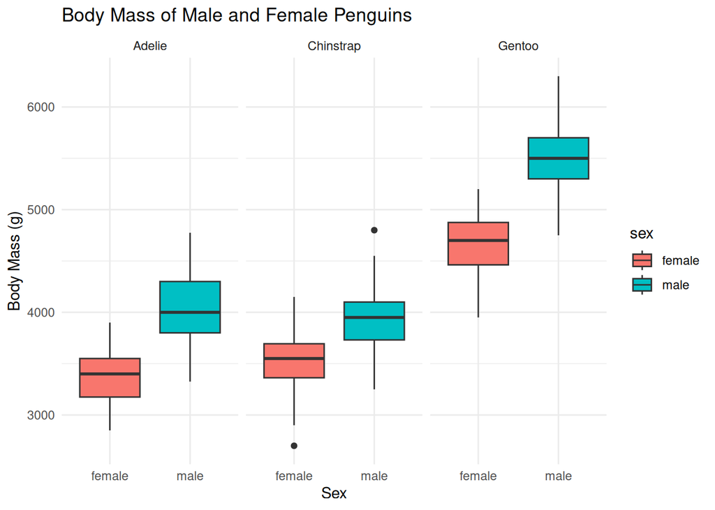

```r
penguins %>%
  filter(!is.na(sex), !is.na(body_mass_g)) %>%
  ggplot(aes(x = sex, y = body_mass_g, fill = sex)) +
  geom_boxplot() +
  facet_wrap(~species) +
  labs(
    title = "Body Mass of Male and Female Penguins",
    x = "Sex",
    y = "Body Mass (g)"
  ) +
  theme_minimal()
```

## Species Comparison

The scatterplot below compares bill length and bill depth among the three penguin species.

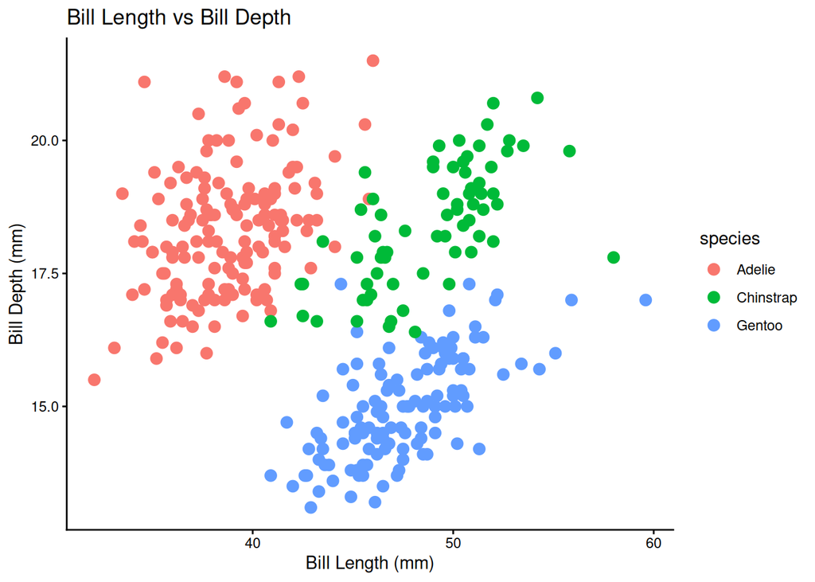

```r
penguins %>%
  filter(!is.na(bill_length_mm), !is.na(bill_depth_mm)) %>%
  ggplot(aes(
    x = bill_length_mm,
    y = bill_depth_mm,
    color = species
  )) +
  geom_point(size = 3) +
  labs(
    title = "Bill Length vs Bill Depth",
    x = "Bill Length (mm)",
    y = "Bill Depth (mm)"
  ) +
  theme_classic()
```

## Penguin Species by Island

The bar chart below shows which penguin species were observed on each island.

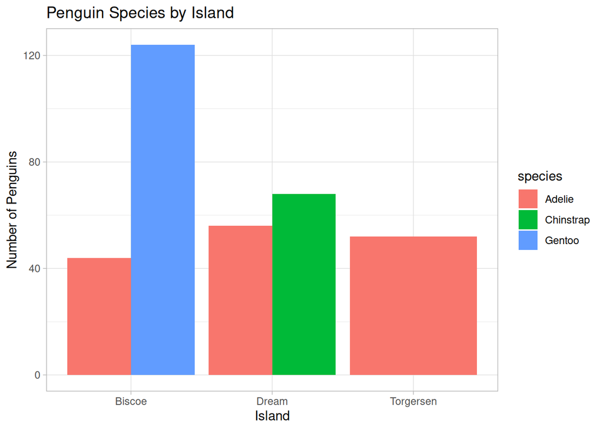

```r
penguins %>%
  count(island, species) %>%
  ggplot(aes(x = island, y = n, fill = species)) +
  geom_col(position = "dodge") +
  labs(
    title = "Penguin Species by Island",
    x = "Island",
    y = "Number of Penguins"
  ) +
  theme_light()
```

# Conclusion

The Palmer Penguins dataset contains measurements from 344 penguins across three species and three islands. The analysis showed that males and females are represented in similar numbers, although not exactly equally. The species and islands are also not represented equally.

Body mass is useful for distinguishing male and female penguins, while bill measurements help distinguish among Adelie, Chinstrap, and Gentoo penguins. The visualizations also show how the three species are distributed across the islands included in the dataset.